# Introduction to toxEval: Passive Data

Steven R. Corsi, Laura A. De Cicco

19 May, 2015

# 1 Introduction

This package **toxEval** is an early test version of the package that will encompass the various approaches to evaluate ToxCast data in relation to measured aquatic concentrations. Data measured in aquatic environments can come in many different formats. This package will use example data measured from passive samplers, as well as water samples taken at a variety of sites around the Great Lakes.

# 2 Passive Data

```
##                    Chemical Units MLD  MQL site04101500 site04102500 site04108660
## 1               Trifluralin  pg/L 190  490         <190         <190         <190
## 2   Hexachlorobenzene (HCB)  pg/L  32   88          130           49           33
## 3  Pentachloroanisole (PCA)  pg/L  69  210          150          160           93
## 4                Tefluthrin  pg/L 130  380         <130         <130         <130
## 5 alpha-Benzenehexachloride  pg/L 190  570         <190         <190         <190
## 6                   Lindane  pg/L 850 2400         <850         <850         <850
```

```
## [1] "pg/L" "ng/L"
```

For this data, the CAS column was used to retrieve the molecular weight (mlWt). Each column is a unique site where the data was collected. Each row is a unique measured chemical.

Some of the data is ‘left-censored’. This means that the measured data was lower than the detection limit of the measurement technique. Values that are found to be lower than the detection limit are indicated by a “<”. The first thing to check is that the method quantitation limit (MQL) or minimum level of detectability (MLD) are low enough to be ignored. That is, MQL and MLD are below the minumum endpoint levels. If so, we can simply remove any values that have the “<” indicator. To begin the study of the endpoints and how they relate to our data, we need to load up the **toxEval** package, and choose an endpoint dataset. We will use the AC50gain dataset in this report.

For this workflow, we will use the units reported by the measured data, meaning we need to convert the ToxCast end points to the units in the “Units” column of the passiveData data frame (we could also do the analysis converting the measured data to $\log$$\mu$M… it shouldn’t matter as long as you are consistent).

```r
library(toxEval)
endPointInfo <- endPointInfo
# AC50 data provided in the toxEval package:
AC50gain <- AC50gain
head(AC50gain[,1:5])
```

```
##        code  chid       casn                     chnm ACEA_T47D_80hr_Negative
## 1   C100005 20281   100-00-5  1-Chloro-4-nitrobenzene                      NA
## 2   C100016 20961   100-01-6           4-Nitroaniline                1.120699
## 3   C100027 21834   100-02-7            4-Nitrophenol                      NA
## 4 C10016203 30698 10016-20-3       alpha-Cyclodextrin                      NA
## 5   C100210 26080   100-21-0        Terephthalic acid                      NA
## 6 C10025748 41909 10025-74-8 Dysprosium(III) chloride                      NA
```

The units in the AC50gain, AC50loss, and AC10 data sets are $\log$$\mu$M. The first step is to convert to the desired unit (pg/L, ng/L) based on the passiveData data frame.

$\require{cancel} \begin{aligned} Reported Data = \log \mu M \\ \mu M = 10^{\log \mu M} \\ MW = \frac{g}{mol} , M = \frac{mol}{L} \\ \cancel{\mu M} \left[\frac{\cancel{M}}{10^6 \cancel{\mu M}}\right] \left[\frac{1}{\cancel{M}} \frac{\cancel{mol}}{L}\right] \left[ \frac{MW \cancel{g}}{\cancel{mol}}\right] \left[\frac{10^9 ng}{\cancel{g}}\right] = MW * 10^3 \frac{ng}{L} \end{aligned}$

```r
library(dplyr)

unitConversion <- setNames(c(10^6, 10^3), c("pg/L", "ng/L") )

AC50 <- right_join(AC50gain[,c("casn"), drop=FALSE],
                   passiveData[,c("CAS", "Units", "mlWt")],
                   by= c("casn" = "CAS")) %>%
  rename(desiredUnits = Units) %>%
  filter(!is.na(mlWt)) %>%
  mutate(conversion = unitConversion[desiredUnits] * mlWt) %>%
  select(casn, desiredUnits, mlWt, conversion)
```

A sample of the AC50 data frame is shown here:

| casn | desiredUnits | mlWt | conversion |
| --- | --- | --- | --- |
| 1582-09-8 | pg/L | 335.28 | 335282300 |
| 118-74-1 | pg/L | 284.78 | 284784000 |
| 1825-21-4 | pg/L | 280.37 | 280365100 |
| 79538-32-2 | pg/L | 418.74 | 418738200 |
| 319-85-7 | pg/L | 290.83 | 290831400 |
| 76-44-8 | pg/L | 373.32 | 373320500 |

Next we can create a data frame with the AC50 converted endpoints:

```r
AC50Converted <- left_join(AC50, AC50gain, by="casn")
infoColumns <- c("casn", "chnm", "desiredUnits","mlWt", "conversion", "code","chid")

endPointData <- AC50Converted[,!(names(AC50Converted) %in% infoColumns)]
endPointData <- 10^endPointData
endPointData <- endPointData * AC50Converted$conversion
endPoint <- cbind(AC50, data.frame(endPointData)) %>%
  rename(Units=desiredUnits) %>%
  filter(rowSums(is.na(endPointData)) != ncol(endPointData))

endPointData <- endPointData[rowSums(is.na(endPointData)) !=
                               ncol(endPointData),]
```

Now, let’s look at the extreme reported endpoint (not including NA’s):

```r
maxEndPoints <- apply(endPointData, 1, max, na.rm=TRUE)
minEndPoints <- apply(endPointData, 1, min, na.rm=TRUE)

maxMinSummary <- cbind(endPoint[,c("casn", "Units")],
                       maxEndPoint=maxEndPoints,
                       minEndPoint=minEndPoints) %>%
  arrange(desc(casn))
```

## 2.1 Passive Detection Limits

Next, let’s determine if the MQL or MLD are going to tell us anything in relation to the ToxCast endpoints. Likewise, we can look at the maximum and minimum measured values.

```
## [1] 0
```

0 measurements have detection limitations that are greater than the minimum endpoint concentration. We might be interested to know how close the detection limit values come to the minimum endpoints.

| Chemical | minEndPoint | MLD | Max EAR | class |
| --- | --- | --- | --- | --- |
| Naphthalene | 11723.73416139 | 2100 | 0.179123815935367 | PAHs |
| Fluorene | 1680.88878471145 | 100 | 0.0594923357866098 | PAHs |
| Aspirin | 13.5480946496618 | 0.424448217 | 0.0313289970269433 | Pharmaceuticals |
| Heptachlor Epoxide | 14653.941219666 | 390 | 0.0266140005718468 | OC Pesticides |
| Erythromycin | 6.95917952763718 | 0.127502231 | 0.0183214458678134 | Pharmaceuticals |
| 1,4-Dichlorobenzene | 80634.2959679285 | 920 | 0.0114095372069215 | Other |

Since it appears that we can ignore the censored values, the easist way to convert data to numbers then is to use the `as.numeric` function. This will convert the left-censored data to `NA`, generating a warning. To convert all the columns with the word ‘site’ in their column name to numeric, use the following commands:

```r
siteColumns <- grep("site",names(passiveData))
passiveData[,siteColumns] <- suppressWarnings(
  sapply(passiveData[,siteColumns], function(x) as.numeric(x)))

#For this analysis, we'll consider NA's to be 0 (other options exist):
passiveData[,siteColumns][is.na(passiveData[,siteColumns])] <- 0
```

## 2.2 Chemical Summary Tables Passive

| Chemical | minEAR | maxEAR | hits | nSites | endPoint | class | type | type_sub | family | family_sub |
| --- | --- | --- | --- | --- | --- | --- | --- | --- | --- | --- |
| Fluorene | 0.101136970837237 | 8.92385036799147 | 29 | 62 | Tox21_NFkB_BLA_agonist_ratio | PAHs | pathway | pathway-specified | dna binding | NF-kappa B |
| Erythromycin | 0.171336054956587 | 1.68622444260814 | 6 | 62 | Tox21_AhR | Pharmaceuticals | protein | receptor | dna binding | basic helix-loop-helix protein |
| Erythromycin | 0.130387186129866 | 1.28322121290108 | 6 | 62 | Tox21_NFkB_BLA_agonist_ratio | Pharmaceuticals | pathway | pathway-specified | dna binding | NF-kappa B |
| Aspirin | 0.184851525602718 | 1.10647304197674 | 16 | 62 | Tox21_TR_LUC_GH3_Antagonist | Pharmaceuticals | protein | receptor | nuclear receptor | non-steroidal |
| Naphthalene | 0.196183226976831 | 0.469133803640247 | 4 | 62 | Tox21_GR_BLA_Antagonist_ratio | PAHs | protein | receptor | nuclear receptor | steroidal |
| Gemfibrozil | 0.270466186339183 | 0.294681791866571 | 2 | 62 | Tox21_AR_BLA_Antagonist_viability |  | cellular | cellular | cell cycle | cytotoxicity |
| Hydrochlorothiazide (HCTZ) | 0.124443425638251 | 0.124443425638251 | 1 | 62 | NVS_ENZ_hPTPN9 |  | protein | enzyme | phosphatase | non-receptor tyrosine phosphatase |

There are actually multiple genes for the endpoint that corresponds to Aspirin/`Tox21_TR_LUC_GH3_Antagonist`.

## 2.3 Passive site summaries

| site | minEAR | maxEAR | hits | nChem | nEndPoints |
| --- | --- | --- | --- | --- | --- |
| IndianaHC | 0.332658515308539 | 8.92385036799147 | 2 | 2 | 2 |
| Sheboygan | 4.52141751978234 | 4.52141751978234 | 1 | 1 | 1 |
| Rouge | 1.10647304197674 | 1.90375474517151 | 2 | 2 | 2 |
| Cuyahoga | 0.339106313983676 | 1.68622444260814 | 3 | 3 | 2 |
| Rocky | 0.154680073045185 | 1.57522864821422 | 3 | 3 | 2 |
| Portage | 0.345055547562337 | 1.52263298682247 | 3 | 3 | 2 |
| StJoseph | 0.190375474517151 | 1.14376364388785 | 4 | 4 | 3 |
| GrandOH | 1.01136970837237 | 1.01136970837237 | 1 | 1 | 1 |
| HuronOH | 0.892385036799147 | 0.892385036799147 | 1 | 1 | 1 |
| Fox | 0.469133803640247 | 0.773400365225927 | 2 | 2 | 2 |

[output cut: 25 more lines]

## 2.4 Passive Site tables

Let’s create a set of summary tables for each site.

### 2.4.1 IndianaHC

IndianaHC

| chnm | EAR | class | endPoint | type | type_sub | family | family_sub |
| --- | --- | --- | --- | --- | --- | --- | --- |
| Fluorene | 8.92 | PAHs | Tox21_NFkB_BLA_agonist_ratio | pathway | pathway-specified | dna binding | NF-kappa B |
| Naphthalene | 0.33 | PAHs | Tox21_GR_BLA_Antagonist_ratio | protein | receptor | nuclear receptor | steroidal |

### 2.4.2 Sheboygan

Sheboygan

| chnm | EAR | class | endPoint | type | type_sub | family | family_sub |
| --- | --- | --- | --- | --- | --- | --- | --- |
| Fluorene | 4.52 | PAHs | Tox21_NFkB_BLA_agonist_ratio | pathway | pathway-specified | dna binding | NF-kappa B |

### 2.4.3 Rouge

Rouge

| chnm | EAR | class | endPoint | type | type_sub | family | family_sub |
| --- | --- | --- | --- | --- | --- | --- | --- |
| Fluorene | 1.90 | PAHs | Tox21_NFkB_BLA_agonist_ratio | pathway | pathway-specified | dna binding | NF-kappa B |
| Aspirin | 1.11 | Pharmaceuticals | Tox21_TR_LUC_GH3_Antagonist | protein | receptor | nuclear receptor | non-steroidal |

### 2.4.4 Cuyahoga

Cuyahoga

| chnm | EAR | class | endPoint | type | type_sub | family | family_sub |
| --- | --- | --- | --- | --- | --- | --- | --- |
| Erythromycin | 1.69 | Pharmaceuticals | Tox21_AhR | protein | receptor | dna binding | basic helix-loop-helix protein |
| Erythromycin | 1.28 | Pharmaceuticals | Tox21_NFkB_BLA_agonist_ratio | pathway | pathway-specified | dna binding | NF-kappa B |
| Fluorene | 0.34 | PAHs | Tox21_NFkB_BLA_agonist_ratio | pathway | pathway-specified | dna binding | NF-kappa B |

### 2.4.5 Rocky

Rocky

| chnm | EAR | class | endPoint | type | type_sub | family | family_sub |
| --- | --- | --- | --- | --- | --- | --- | --- |
| Erythromycin | 1.58 | Pharmaceuticals | Tox21_AhR | protein | receptor | dna binding | basic helix-loop-helix protein |
| Erythromycin | 1.20 | Pharmaceuticals | Tox21_NFkB_BLA_agonist_ratio | pathway | pathway-specified | dna binding | NF-kappa B |
| Fluorene | 0.15 | PAHs | Tox21_NFkB_BLA_agonist_ratio | pathway | pathway-specified | dna binding | NF-kappa B |

### 2.4.6 Portage

Portage

| chnm | EAR | class | endPoint | type | type_sub | family | family_sub |
| --- | --- | --- | --- | --- | --- | --- | --- |
| Erythromycin | 1.52 | Pharmaceuticals | Tox21_AhR | protein | receptor | dna binding | basic helix-loop-helix protein |
| Erythromycin | 1.16 | Pharmaceuticals | Tox21_NFkB_BLA_agonist_ratio | pathway | pathway-specified | dna binding | NF-kappa B |
| Fluorene | 0.35 | PAHs | Tox21_NFkB_BLA_agonist_ratio | pathway | pathway-specified | dna binding | NF-kappa B |

### 2.4.7 StJoseph

StJoseph

| chnm | EAR | class | endPoint | type | type_sub | family | family_sub |
| --- | --- | --- | --- | --- | --- | --- | --- |
| Erythromycin | 1.14 | Pharmaceuticals | Tox21_AhR | protein | receptor | dna binding | basic helix-loop-helix protein |
| Erythromycin | 0.87 | Pharmaceuticals | Tox21_NFkB_BLA_agonist_ratio | pathway | pathway-specified | dna binding | NF-kappa B |
| Aspirin | 0.27 | Pharmaceuticals | Tox21_TR_LUC_GH3_Antagonist | protein | receptor | nuclear receptor | non-steroidal |
| Fluorene | 0.19 | PAHs | Tox21_NFkB_BLA_agonist_ratio | pathway | pathway-specified | dna binding | NF-kappa B |

### 2.4.8 GrandOH

GrandOH

| chnm | EAR | class | endPoint | type | type_sub | family | family_sub |
| --- | --- | --- | --- | --- | --- | --- | --- |
| Fluorene | 1.01 | PAHs | Tox21_NFkB_BLA_agonist_ratio | pathway | pathway-specified | dna binding | NF-kappa B |

### 2.4.9 HuronOH

HuronOH

| chnm | EAR | class | endPoint | type | type_sub | family | family_sub |
| --- | --- | --- | --- | --- | --- | --- | --- |
| Fluorene | 0.89 | PAHs | Tox21_NFkB_BLA_agonist_ratio | pathway | pathway-specified | dna binding | NF-kappa B |

### 2.4.10 Fox

Fox

| chnm | EAR | class | endPoint | type | type_sub | family | family_sub |
| --- | --- | --- | --- | --- | --- | --- | --- |
| Fluorene | 0.77 | PAHs | Tox21_NFkB_BLA_agonist_ratio | pathway | pathway-specified | dna binding | NF-kappa B |
| Naphthalene | 0.47 | PAHs | Tox21_GR_BLA_Antagonist_ratio | protein | receptor | nuclear receptor | steroidal |

### 2.4.11 Clinton

Clinton

| chnm | EAR | class | endPoint | type | type_sub | family | family_sub |
| --- | --- | --- | --- | --- | --- | --- | --- |
| Fluorene | 0.65 | PAHs | Tox21_NFkB_BLA_agonist_ratio | pathway | pathway-specified | dna binding | NF-kappa B |
| Aspirin | 0.57 | Pharmaceuticals | Tox21_TR_LUC_GH3_Antagonist | protein | receptor | nuclear receptor | non-steroidal |
| Erythromycin | 0.26 | Pharmaceuticals | Tox21_AhR | protein | receptor | dna binding | basic helix-loop-helix protein |
| Erythromycin | 0.19 | Pharmaceuticals | Tox21_NFkB_BLA_agonist_ratio | pathway | pathway-specified | dna binding | NF-kappa B |
| Hydrochlorothiazide (HCTZ) | 0.12 | NA | NVS_ENZ_hPTPN9 | protein | enzyme | phosphatase | non-receptor tyrosine phosphatase |

### 2.4.12 BlackOH

BlackOH

| chnm | EAR | class | endPoint | type | type_sub | family | family_sub |
| --- | --- | --- | --- | --- | --- | --- | --- |
| Fluorene | 0.58 | PAHs | Tox21_NFkB_BLA_agonist_ratio | pathway | pathway-specified | dna binding | NF-kappa B |

### 2.4.13 Indian

Indian

| chnm | EAR | class | endPoint | type | type_sub | family | family_sub |
| --- | --- | --- | --- | --- | --- | --- | --- |
| Fluorene | 0.48 | PAHs | Tox21_NFkB_BLA_agonist_ratio | pathway | pathway-specified | dna binding | NF-kappa B |

### 2.4.14 Raisin

Raisin

| chnm | EAR | class | endPoint | type | type_sub | family | family_sub |
| --- | --- | --- | --- | --- | --- | --- | --- |
| Aspirin | 0.45 | Pharmaceuticals | Tox21_TR_LUC_GH3_Antagonist | protein | receptor | nuclear receptor | non-steroidal |
| Fluorene | 0.15 | PAHs | Tox21_NFkB_BLA_agonist_ratio | pathway | pathway-specified | dna binding | NF-kappa B |

### 2.4.15 PawPaw

PawPaw

| chnm | EAR | class | endPoint | type | type_sub | family | family_sub |
| --- | --- | --- | --- | --- | --- | --- | --- |
| Aspirin | 0.43 | Pharmaceuticals | Tox21_TR_LUC_GH3_Antagonist | protein | receptor | nuclear receptor | non-steroidal |
| Fluorene | 0.36 | PAHs | Tox21_NFkB_BLA_agonist_ratio | pathway | pathway-specified | dna binding | NF-kappa B |

### 2.4.16 Saginaw

Saginaw

| chnm | EAR | class | endPoint | type | type_sub | family | family_sub |
| --- | --- | --- | --- | --- | --- | --- | --- |
| Aspirin | 0.42 | Pharmaceuticals | Tox21_TR_LUC_GH3_Antagonist | protein | receptor | nuclear receptor | non-steroidal |
| Gemfibrozil | 0.29 | NA | Tox21_AR_BLA_Antagonist_viability | cellular | cellular | cell cycle | cytotoxicity |
| Fluorene | 0.15 | PAHs | Tox21_NFkB_BLA_agonist_ratio | pathway | pathway-specified | dna binding | NF-kappa B |

### 2.4.17 StLouis

StLouis

| chnm | EAR | class | endPoint | type | type_sub | family | family_sub |
| --- | --- | --- | --- | --- | --- | --- | --- |
| Fluorene | 0.4 | PAHs | Tox21_NFkB_BLA_agonist_ratio | pathway | pathway-specified | dna binding | NF-kappa B |

### 2.4.18 HuronMI

HuronMI

| chnm | EAR | class | endPoint | type | type_sub | family | family_sub |
| --- | --- | --- | --- | --- | --- | --- | --- |
| Fluorene | 0.35 | PAHs | Tox21_NFkB_BLA_agonist_ratio | pathway | pathway-specified | dna binding | NF-kappa B |

### 2.4.19 GrandMI

GrandMI

| chnm | EAR | class | endPoint | type | type_sub | family | family_sub |
| --- | --- | --- | --- | --- | --- | --- | --- |
| Aspirin | 0.33 | Pharmaceuticals | Tox21_TR_LUC_GH3_Antagonist | protein | receptor | nuclear receptor | non-steroidal |
| Gemfibrozil | 0.27 | NA | Tox21_AR_BLA_Antagonist_viability | cellular | cellular | cell cycle | cytotoxicity |
| Fluorene | 0.14 | PAHs | Tox21_NFkB_BLA_agonist_ratio | pathway | pathway-specified | dna binding | NF-kappa B |

### 2.4.20 Ontonagon

Ontonagon

| chnm | EAR | class | endPoint | type | type_sub | family | family_sub |
| --- | --- | --- | --- | --- | --- | --- | --- |
| Fluorene | 0.32 | PAHs | Tox21_NFkB_BLA_agonist_ratio | pathway | pathway-specified | dna binding | NF-kappa B |
| Aspirin | 0.26 | Pharmaceuticals | Tox21_TR_LUC_GH3_Antagonist | protein | receptor | nuclear receptor | non-steroidal |
| Naphthalene | 0.20 | PAHs | Tox21_GR_BLA_Antagonist_ratio | protein | receptor | nuclear receptor | steroidal |

### 2.4.21 BlackMI

BlackMI

| chnm | EAR | class | endPoint | type | type_sub | family | family_sub |
| --- | --- | --- | --- | --- | --- | --- | --- |
| Aspirin | 0.28 | Pharmaceuticals | Tox21_TR_LUC_GH3_Antagonist | protein | receptor | nuclear receptor | non-steroidal |
| Fluorene | 0.10 | PAHs | Tox21_NFkB_BLA_agonist_ratio | pathway | pathway-specified | dna binding | NF-kappa B |

### 2.4.22 Manistique

Manistique

| chnm | EAR | class | endPoint | type | type_sub | family | family_sub |
| --- | --- | --- | --- | --- | --- | --- | --- |
| Fluorene | 0.28 | PAHs | Tox21_NFkB_BLA_agonist_ratio | pathway | pathway-specified | dna binding | NF-kappa B |

### 2.4.23 Manistee

Manistee

| chnm | EAR | class | endPoint | type | type_sub | family | family_sub |
| --- | --- | --- | --- | --- | --- | --- | --- |
| Aspirin | 0.27 | Pharmaceuticals | Tox21_TR_LUC_GH3_Antagonist | protein | receptor | nuclear receptor | non-steroidal |

### 2.4.24 Kalamazoo2

Kalamazoo2

| chnm | EAR | class | endPoint | type | type_sub | family | family_sub |
| --- | --- | --- | --- | --- | --- | --- | --- |
| Fluorene | 0.27 | PAHs | Tox21_NFkB_BLA_agonist_ratio | pathway | pathway-specified | dna binding | NF-kappa B |
| Aspirin | 0.26 | Pharmaceuticals | Tox21_TR_LUC_GH3_Antagonist | protein | receptor | nuclear receptor | non-steroidal |

### 2.4.25 Burns

Burns

| chnm | EAR | class | endPoint | type | type_sub | family | family_sub |
| --- | --- | --- | --- | --- | --- | --- | --- |
| Fluorene | 0.26 | PAHs | Tox21_NFkB_BLA_agonist_ratio | pathway | pathway-specified | dna binding | NF-kappa B |
| Naphthalene | 0.22 | PAHs | Tox21_GR_BLA_Antagonist_ratio | protein | receptor | nuclear receptor | steroidal |

### 2.4.26 Rifle

Rifle

| chnm | EAR | class | endPoint | type | type_sub | family | family_sub |
| --- | --- | --- | --- | --- | --- | --- | --- |
| Aspirin | 0.25 | Pharmaceuticals | Tox21_TR_LUC_GH3_Antagonist | protein | receptor | nuclear receptor | non-steroidal |

### 2.4.27 WhiteMI

WhiteMI

| chnm | EAR | class | endPoint | type | type_sub | family | family_sub |
| --- | --- | --- | --- | --- | --- | --- | --- |
| Aspirin | 0.25 | Pharmaceuticals | Tox21_TR_LUC_GH3_Antagonist | protein | receptor | nuclear receptor | non-steroidal |

### 2.4.28 PereMarquette

PereMarquette

| chnm | EAR | class | endPoint | type | type_sub | family | family_sub |
| --- | --- | --- | --- | --- | --- | --- | --- |
| Aspirin | 0.21 | Pharmaceuticals | Tox21_TR_LUC_GH3_Antagonist | protein | receptor | nuclear receptor | non-steroidal |

### 2.4.29 Muskegon

Muskegon

| chnm | EAR | class | endPoint | type | type_sub | family | family_sub |
| --- | --- | --- | --- | --- | --- | --- | --- |
| Aspirin | 0.19 | Pharmaceuticals | Tox21_TR_LUC_GH3_Antagonist | protein | receptor | nuclear receptor | non-steroidal |
| Erythromycin | 0.17 | Pharmaceuticals | Tox21_AhR | protein | receptor | dna binding | basic helix-loop-helix protein |
| Erythromycin | 0.13 | Pharmaceuticals | Tox21_NFkB_BLA_agonist_ratio | pathway | pathway-specified | dna binding | NF-kappa B |

### 2.4.30 ThunderBay

ThunderBay

| chnm | EAR | class | endPoint | type | type_sub | family | family_sub |
| --- | --- | --- | --- | --- | --- | --- | --- |
| Aspirin | 0.18 | Pharmaceuticals | Tox21_TR_LUC_GH3_Antagonist | protein | receptor | nuclear receptor | non-steroidal |

### 2.4.31 BlackNY

BlackNY

| chnm | EAR | class | endPoint | type | type_sub | family | family_sub |
| --- | --- | --- | --- | --- | --- | --- | --- |
| Fluorene | 0.18 | PAHs | Tox21_NFkB_BLA_agonist_ratio | pathway | pathway-specified | dna binding | NF-kappa B |

### 2.4.32 StRegis

StRegis

| chnm | EAR | class | endPoint | type | type_sub | family | family_sub |
| --- | --- | --- | --- | --- | --- | --- | --- |
| Fluorene | 0.14 | PAHs | Tox21_NFkB_BLA_agonist_ratio | pathway | pathway-specified | dna binding | NF-kappa B |

### 2.4.33 Grass

Grass

| chnm | EAR | class | endPoint | type | type_sub | family | family_sub |
| --- | --- | --- | --- | --- | --- | --- | --- |
| Fluorene | 0.12 | PAHs | Tox21_NFkB_BLA_agonist_ratio | pathway | pathway-specified | dna binding | NF-kappa B |

### 2.4.34 Maumee

Maumee

| chnm | EAR | class | endPoint | type | type_sub | family | family_sub |
| --- | --- | --- | --- | --- | --- | --- | --- |
| Fluorene | 0.12 | PAHs | Tox21_NFkB_BLA_agonist_ratio | pathway | pathway-specified | dna binding | NF-kappa B |

### 2.4.35 Oswego

Oswego

| chnm | EAR | class | endPoint | type | type_sub | family | family_sub |
| --- | --- | --- | --- | --- | --- | --- | --- |
| Fluorene | 0.11 | PAHs | Tox21_NFkB_BLA_agonist_ratio | pathway | pathway-specified | dna binding | NF-kappa B |

## 2.5 Passive visualizations

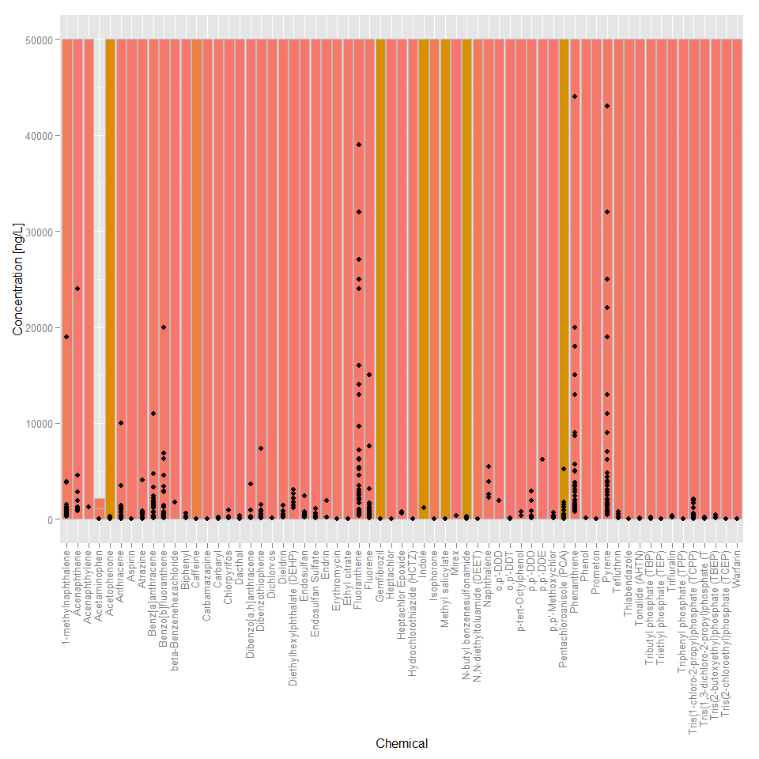

Colors represent different endpoints, dots represent measured passive water sample values